# Python Project - ( Exploration on Prosper Load Dataset)

## by (Chukwudi Onwuegbuchulam)

## Introduction

This dataset is a financial one, and its subjects include loans, borrowers, lenders, interest rates, and similar matters. Loans at affordable rates are the company's specialty at San Francisco's Prosper or Prosper Marketplace Inc. The 81 variables associated with each loan in the dataset include interest rate, loan status, borrower income, borrower employment status, borrower credit history, and more. The key objectives of this project are to use summary statistics and data visualisations to depict the features of elements that might affect loan status and to gain some insight into the interactions between various variables.

## Preliminary Wrangling

The first step is to import the necessary libraries and packages. In order to load our data and perform fast, vectorized operations on it, we will bring in the Numpy and Pandas libraries, and then the Matplotlib and Seaborn libraries, to enable us create informative visualisations:

```python
# import all packages
import numpy as np
import pandas as pd
import matplotlib.pyplot as plt
import seaborn as sns
```

```python
#Loading the Dataset using Pandas
df=pd.read_csv('prosper loan.csv');
df.head()
```

|  | ListingKey | ListingNumber | ListingCreationDate | CreditGrade | Term | LoanStatus | ClosedDate | BorrowerAPR | BorrowerRate | LenderYield | ... | LP_ServiceFees | LP_CollectionFees | LP_GrossPrincipalLoss | LP_NetPrincipalLoss | LP_NonPrincipalRecoverypayments | PercentFunded | Recommendations | InvestmentFromFriendsCount | InvestmentFromFriendsAmount | Investors |
| --- | --- | --- | --- | --- | --- | --- | --- | --- | --- | --- | --- | --- | --- | --- | --- | --- | --- | --- | --- | --- | --- |
| 0 | 1021339766868145413AB3B | 193129 | 09:29.3 | C | 36 | Completed | 14/08/2009 00:00 | 0.16516 | 0.1580 | 0.1380 | ... | -133.18 | 0.0 | 0.0 | 0.0 | 0.0 | 1.0 | 0 | 0 | 0.0 | 258 |
| 1 | 10273602499503308B223C1 | 1209647 | 28:07.9 | NaN | 36 | Current | NaN | 0.12016 | 0.0920 | 0.0820 | ... | 0.00 | 0.0 | 0.0 | 0.0 | 0.0 | 1.0 | 0 | 0 | 0.0 | 1 |
| 2 | 0EE9337825851032864889A | 81716 | 00:47.1 | HR | 36 | Completed | 17/12/2009 00:00 | 0.28269 | 0.2750 | 0.2400 | ... | -24.20 | 0.0 | 0.0 | 0.0 | 0.0 | 1.0 | 0 | 0 | 0.0 | 41 |
| 3 | 0EF5356002482715299901A | 658116 | 02:35.0 | NaN | 36 | Current | NaN | 0.12528 | 0.0974 | 0.0874 | ... | -108.01 | 0.0 | 0.0 | 0.0 | 0.0 | 1.0 | 0 | 0 | 0.0 | 158 |
| 4 | 0F023589499656230C5E3E2 | 909464 | 38:39.1 | NaN | 36 | Current | NaN | 0.24614 | 0.2085 | 0.1985 | ... | -60.27 | 0.0 | 0.0 | 0.0 | 0.0 | 1.0 | 0 | 0 | 0.0 | 20 |

5 rows × 81 columns

### Structure of dataset

```python
df.shape
```

```
(113937, 81)
```

```python
# Display quick summary information about the dataframe
df.info()
```

```
<class 'pandas.core.frame.DataFrame'>
RangeIndex: 113937 entries, 0 to 113936
Data columns (total 81 columns):
 #   Column                               Non-Null Count   Dtype
---  ------                               --------------   -----
 0   ListingKey                           113937 non-null  object
 1   ListingNumber                        113937 non-null  int64
 2   ListingCreationDate                  113937 non-null  object
 3   CreditGrade                          28953 non-null   object
 4   Term                                 113937 non-null  int64
 5   LoanStatus                           113937 non-null  object
 6   ClosedDate                           55089 non-null   object
 7   BorrowerAPR                          113912 non-null  float64
 8   BorrowerRate                         113937 non-null  float64
 9   LenderYield                          113937 non-null  float64
```

[output cut: 73 more lines]

The dataframe has a total of 113,937 rows and 81 columns in its entirety (features). In this table, there are 81 columns total, and 56 of them include information, the majority of which is numerical. The wealth of information that accompanies each loan is used to compile a thorough description that is included in the dataset.

### features of interest

The dataset reveals that several of the features have values that are unmatched by any other. These standards are not significant. These features are 1- ListingKey, 2- ListingNumber , 3- GroupKey 4- LoanKey ,5- LoanNumber , 6- MemberKey

```python
df.describe()
```

|  | ListingNumber | Term | BorrowerAPR | BorrowerRate | LenderYield | EstimatedEffectiveYield | EstimatedLoss | EstimatedReturn | ProsperRating (numeric) | ProsperScore | ... | LP_ServiceFees | LP_CollectionFees | LP_GrossPrincipalLoss | LP_NetPrincipalLoss | LP_NonPrincipalRecoverypayments | PercentFunded | Recommendations | InvestmentFromFriendsCount | InvestmentFromFriendsAmount | Investors |
| --- | --- | --- | --- | --- | --- | --- | --- | --- | --- | --- | --- | --- | --- | --- | --- | --- | --- | --- | --- | --- | --- |
| count | 1.139370e+05 | 113937.000000 | 113912.000000 | 113937.000000 | 113937.000000 | 84853.000000 | 84853.000000 | 84853.000000 | 84853.000000 | 84853.000000 | ... | 113937.000000 | 113937.000000 | 113937.000000 | 113937.000000 | 113937.000000 | 113937.000000 | 113937.000000 | 113937.000000 | 113937.000000 | 113937.000000 |
| mean | 6.278857e+05 | 40.830248 | 0.218828 | 0.192764 | 0.182701 | 0.168661 | 0.080306 | 0.096068 | 4.072243 | 5.950067 | ... | -54.725641 | -14.242698 | 700.446342 | 681.420499 | 25.142686 | 0.998584 | 0.048027 | 0.023460 | 16.550751 | 80.475228 |
| std | 3.280762e+05 | 10.436212 | 0.080364 | 0.074818 | 0.074516 | 0.068467 | 0.046764 | 0.030403 | 1.673227 | 2.376501 | ... | 60.675425 | 109.232758 | 2388.513831 | 2357.167068 | 275.657937 | 0.017919 | 0.332353 | 0.232412 | 294.545422 | 103.239020 |
| min | 4.000000e+00 | 12.000000 | 0.006530 | 0.000000 | -0.010000 | -0.182700 | 0.004900 | -0.182700 | 1.000000 | 1.000000 | ... | -664.870000 | -9274.750000 | -94.200000 | -954.550000 | 0.000000 | 0.700000 | 0.000000 | 0.000000 | 0.000000 | 1.000000 |
| 25% | 4.009190e+05 | 36.000000 | 0.156290 | 0.134000 | 0.124200 | 0.115670 | 0.042400 | 0.074080 | 3.000000 | 4.000000 | ... | -73.180000 | 0.000000 | 0.000000 | 0.000000 | 0.000000 | 1.000000 | 0.000000 | 0.000000 | 0.000000 | 2.000000 |
| 50% | 6.005540e+05 | 36.000000 | 0.209760 | 0.184000 | 0.173000 | 0.161500 | 0.072400 | 0.091700 | 4.000000 | 6.000000 | ... | -34.440000 | 0.000000 | 0.000000 | 0.000000 | 0.000000 | 1.000000 | 0.000000 | 0.000000 | 0.000000 | 44.000000 |
| 75% | 8.926340e+05 | 36.000000 | 0.283810 | 0.250000 | 0.240000 | 0.224300 | 0.112000 | 0.116600 | 5.000000 | 8.000000 | ... | -13.920000 | 0.000000 | 0.000000 | 0.000000 | 0.000000 | 1.000000 | 0.000000 | 0.000000 | 0.000000 | 115.000000 |
| max | 1.255725e+06 | 60.000000 | 0.512290 | 0.497500 | 0.492500 | 0.319900 | 0.366000 | 0.283700 | 7.000000 | 11.000000 | ... | 32.060000 | 0.000000 | 25000.000000 | 25000.000000 | 21117.900000 | 1.012500 | 39.000000 | 33.000000 | 25000.000000 | 1189.000000 |

8 rows × 61 columns

```python
df.drop(columns=["ListingKey","ListingNumber","GroupKey","LoanKey","LoanNumber","MemberKey","DateCreditPulled"],
    inplace= True );
```

We will descover null values and we will handle it

```python
df.isnull().sum()
```

```
ListingCreationDate                0
CreditGrade                    84984
Term                               0
LoanStatus                         0
ClosedDate                     58848
                               ...
PercentFunded                      0
Recommendations                    0
InvestmentFromFriendsCount         0
InvestmentFromFriendsAmount        0
Investors                          0
Length: 74, dtype: int64
```

```python
x = df.isnull().sum()
for i in range(len(x)) :
    print( str(i) + "  : " + str(x[i]) )
```

```
0  : 0
1  : 84984
2  : 0
3  : 0
4  : 58848
5  : 25
6  : 0
7  : 0
8  : 29084
9  : 29084
10  : 29084
11  : 29084
12  : 29084
13  : 29084
14  : 0
```

[output cut: 59 more lines]

```python
def null_values() :
    lst = df.isnull().sum()
    for i in range(len(lst)) :
        if lst[i] != 0 :
            x= lst[i]
            col = df.columns[i]
            y= (x/df.shape[0])*100
            print("col num : " +str(i) + " /  " + col + " / " + str(x) + " nulls /"+ str(round(y,2)) +" %")
null_values()
```

```
col num : 1 /  CreditGrade / 84984 nulls /74.59 %
col num : 4 /  ClosedDate / 58848 nulls /51.65 %
col num : 5 /  BorrowerAPR / 25 nulls /0.02 %
col num : 8 /  EstimatedEffectiveYield / 29084 nulls /25.53 %
col num : 9 /  EstimatedLoss / 29084 nulls /25.53 %
col num : 10 /  EstimatedReturn / 29084 nulls /25.53 %
col num : 11 /  ProsperRating (numeric) / 29084 nulls /25.53 %
col num : 12 /  ProsperRating (Alpha) / 29084 nulls /25.53 %
col num : 13 /  ProsperScore / 29084 nulls /25.53 %
col num : 15 /  BorrowerState / 5515 nulls /4.84 %
col num : 16 /  Occupation / 3588 nulls /3.15 %
col num : 17 /  EmploymentStatus / 2255 nulls /1.98 %
col num : 18 /  EmploymentStatusDuration / 7625 nulls /6.69 %
col num : 21 /  CreditScoreRangeLower / 591 nulls /0.52 %
col num : 22 /  CreditScoreRangeUpper / 591 nulls /0.52 %
col num : 23 /  FirstRecordedCreditLine / 697 nulls /0.61 %
col num : 24 /  CurrentCreditLines / 7604 nulls /6.67 %
col num : 25 /  OpenCreditLines / 7604 nulls /6.67 %
col num : 26 /  TotalCreditLinespast7years / 697 nulls /0.61 %
col num : 29 /  InquiriesLast6Months / 697 nulls /0.61 %
col num : 30 /  TotalInquiries / 1159 nulls /1.02 %
col num : 31 /  CurrentDelinquencies / 697 nulls /0.61 %
col num : 32 /  AmountDelinquent / 7622 nulls /6.69 %
col num : 33 /  DelinquenciesLast7Years / 990 nulls /0.87 %
col num : 34 /  PublicRecordsLast10Years / 697 nulls /0.61 %
col num : 35 /  PublicRecordsLast12Months / 7604 nulls /6.67 %
col num : 36 /  RevolvingCreditBalance / 7604 nulls /6.67 %
col num : 37 /  BankcardUtilization / 7604 nulls /6.67 %
col num : 38 /  AvailableBankcardCredit / 7544 nulls /6.62 %
col num : 39 /  TotalTrades / 7544 nulls /6.62 %
col num : 40 /  TradesNeverDelinquent (percentage) / 7544 nulls /6.62 %
col num : 41 /  TradesOpenedLast6Months / 7544 nulls /6.62 %
col num : 42 /  DebtToIncomeRatio / 8554 nulls /7.51 %
col num : 46 /  TotalProsperLoans / 91852 nulls /80.62 %
col num : 47 /  TotalProsperPaymentsBilled / 91852 nulls /80.62 %
col num : 48 /  OnTimeProsperPayments / 91852 nulls /80.62 %
col num : 49 /  ProsperPaymentsLessThanOneMonthLate / 91852 nulls /80.62 %
col num : 50 /  ProsperPaymentsOneMonthPlusLate / 91852 nulls /80.62 %
col num : 51 /  ProsperPrincipalBorrowed / 91852 nulls /80.62 %
col num : 52 /  ProsperPrincipalOutstanding / 91852 nulls /80.62 %
col num : 53 /  ScorexChangeAtTimeOfListing / 95009 nulls /83.39 %
col num : 55 /  LoanFirstDefaultedCycleNumber / 96985 nulls /85.12 %
```

We are going to eliminate features that have more than 50% nulls.

```python
df.drop(columns=["CreditGrade","TotalProsperLoans","TotalProsperPaymentsBilled",
                 "ProsperPaymentsLessThanOneMonthLate","ProsperPaymentsOneMonthPlusLate","ProsperPrincipalBorrowed",
                "ProsperPrincipalOutstanding","ScorexChangeAtTimeOfListing","LoanFirstDefaultedCycleNumber","OnTimeProsperPayments",
                "ClosedDate"],inplace= True )
```

```python
null_values()
```

```
col num : 3 /  BorrowerAPR / 25 nulls /0.02 %
col num : 6 /  EstimatedEffectiveYield / 29084 nulls /25.53 %
col num : 7 /  EstimatedLoss / 29084 nulls /25.53 %
col num : 8 /  EstimatedReturn / 29084 nulls /25.53 %
col num : 9 /  ProsperRating (numeric) / 29084 nulls /25.53 %
col num : 10 /  ProsperRating (Alpha) / 29084 nulls /25.53 %
col num : 11 /  ProsperScore / 29084 nulls /25.53 %
col num : 13 /  BorrowerState / 5515 nulls /4.84 %
col num : 14 /  Occupation / 3588 nulls /3.15 %
col num : 15 /  EmploymentStatus / 2255 nulls /1.98 %
col num : 16 /  EmploymentStatusDuration / 7625 nulls /6.69 %
col num : 19 /  CreditScoreRangeLower / 591 nulls /0.52 %
col num : 20 /  CreditScoreRangeUpper / 591 nulls /0.52 %
col num : 21 /  FirstRecordedCreditLine / 697 nulls /0.61 %
col num : 22 /  CurrentCreditLines / 7604 nulls /6.67 %
col num : 23 /  OpenCreditLines / 7604 nulls /6.67 %
col num : 24 /  TotalCreditLinespast7years / 697 nulls /0.61 %
col num : 27 /  InquiriesLast6Months / 697 nulls /0.61 %
col num : 28 /  TotalInquiries / 1159 nulls /1.02 %
col num : 29 /  CurrentDelinquencies / 697 nulls /0.61 %
col num : 30 /  AmountDelinquent / 7622 nulls /6.69 %
col num : 31 /  DelinquenciesLast7Years / 990 nulls /0.87 %
col num : 32 /  PublicRecordsLast10Years / 697 nulls /0.61 %
col num : 33 /  PublicRecordsLast12Months / 7604 nulls /6.67 %
col num : 34 /  RevolvingCreditBalance / 7604 nulls /6.67 %
col num : 35 /  BankcardUtilization / 7604 nulls /6.67 %
col num : 36 /  AvailableBankcardCredit / 7544 nulls /6.62 %
col num : 37 /  TotalTrades / 7544 nulls /6.62 %
col num : 38 /  TradesNeverDelinquent (percentage) / 7544 nulls /6.62 %
col num : 39 /  TradesOpenedLast6Months / 7544 nulls /6.62 %
col num : 40 /  DebtToIncomeRatio / 8554 nulls /7.51 %
```

```python
df.dropna(subset=["EstimatedEffectiveYield","EstimatedLoss","EstimatedReturn","ProsperRating (numeric)",
"ProsperRating (Alpha)","ProsperScore"],inplace = True)
```

```python
null_values()
```

```
col num : 14 /  Occupation / 1333 nulls /1.57 %
col num : 16 /  EmploymentStatusDuration / 19 nulls /0.02 %
col num : 40 /  DebtToIncomeRatio / 7296 nulls /8.6 %
```

```python
df["DebtToIncomeRatio"].describe()
```

```
count    77557.000000
mean         0.258752
std          0.318326
min          0.000000
25%          0.150000
50%          0.220000
75%          0.320000
max         10.010000
Name: DebtToIncomeRatio, dtype: float64
```

```python
df["DebtToIncomeRatio"].value_counts()
```

```
0.18    3213
0.22    2999
0.17    2749
0.14    2703
0.21    2578
        ...
1.54       1
3.81       1
4.54       1
1.93       1
2.53       1
Name: DebtToIncomeRatio, Length: 259, dtype: int64
```

```python
df["DebtToIncomeRatio"].fillna(df["DebtToIncomeRatio"].mean,inplace = True)
```

```python
df.dropna(inplace = True)
```

```python
df.isna().info()
```

```
<class 'pandas.core.frame.DataFrame'>
Int64Index: 83507 entries, 1 to 113936
Data columns (total 63 columns):
 #   Column                              Non-Null Count  Dtype
---  ------                              --------------  -----
 0   ListingCreationDate                 83507 non-null  bool
 1   Term                                83507 non-null  bool
 2   LoanStatus                          83507 non-null  bool
 3   BorrowerAPR                         83507 non-null  bool
 4   BorrowerRate                        83507 non-null  bool
 5   LenderYield                         83507 non-null  bool
 6   EstimatedEffectiveYield             83507 non-null  bool
 7   EstimatedLoss                       83507 non-null  bool
 8   EstimatedReturn                     83507 non-null  bool
 9   ProsperRating (numeric)             83507 non-null  bool
```

[output cut: 55 more lines]

Handling the date features:1- ListingCreationDate , 2- ClosedDate 3- DateCreditPulled 4- FirstRecordedCreditLine , 5- LoanOriginationDate

```python
df[["ListingCreationDate","FirstRecordedCreditLine","LoanOriginationDate"]].head()
```

|  | ListingCreationDate | FirstRecordedCreditLine | LoanOriginationDate |
| --- | --- | --- | --- |
| 1 | 28:07.9 | 18/03/1996 00:00 | 03/03/2014 00:00 |
| 3 | 02:35.0 | 28/02/1983 00:00 | 01/11/2012 00:00 |
| 4 | 38:39.1 | 20/02/2004 00:00 | 20/09/2013 00:00 |
| 5 | 26:37.1 | 01/03/1973 00:00 | 24/12/2013 00:00 |
| 6 | 52:56.1 | 29/09/2000 00:00 | 18/04/2013 00:00 |

```python
df["ListingCreationDate"] = df["ListingCreationDate"].str.extract(r"^(\w+)")
df["FirstRecordedCreditLine"] = df["FirstRecordedCreditLine"].str.extract(r"^(\w+)")
df["LoanOriginationDate"] = df["LoanOriginationDate"].str.extract(r"^(\w+)")
```

```python
df.info()
```

```
<class 'pandas.core.frame.DataFrame'>
Int64Index: 83507 entries, 1 to 113936
Data columns (total 63 columns):
 #   Column                              Non-Null Count  Dtype
---  ------                              --------------  -----
 0   ListingCreationDate                 83507 non-null  object
 1   Term                                83507 non-null  int64
 2   LoanStatus                          83507 non-null  object
 3   BorrowerAPR                         83507 non-null  float64
 4   BorrowerRate                        83507 non-null  float64
 5   LenderYield                         83507 non-null  float64
 6   EstimatedEffectiveYield             83507 non-null  float64
 7   EstimatedLoss                       83507 non-null  float64
 8   EstimatedReturn                     83507 non-null  float64
 9   ProsperRating (numeric)             83507 non-null  float64
```

[output cut: 55 more lines]

# A. Univariate Exploration

The BorrowerAPR (Annual percentage rate) is one of our key features of interest. Let's start by exploring how the feature is distributed throughout our loan dataset:

Question One: How are Borrower APR values distributed in the dataset, do the majority of loans have high or low APR values? Visualization

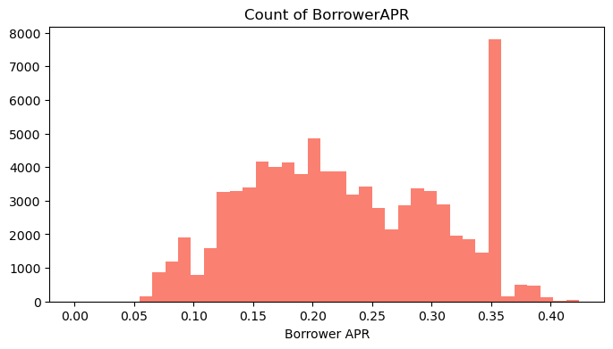

```python
# Set color for all univariate plots
colors = sns.color_palette('Paired')

# Create 40 evenly spaced bins for Borrower APR from zero to the maximum value
bins = np.linspace(0, df.BorrowerAPR.max(), 40)

plt.figure(figsize=(8, 4))
plt.hist(data=df, x='BorrowerAPR', bins=bins, color = 'Salmon');
plt.xticks(np.arange(0, 0.45, 0.05))
plt.xlabel('Borrower APR')
plt.title('Count of BorrowerAPR');
```

Observations Borrower APR appears to follow a multimodal distribution, with peaks around 0.09, 0.2 and 0.3 respectively. A very sharp peak can also be seen between 0.35 and 0.36. In general, only few listings have borrower APR greater than 0.4.

Question 2: Count of loan status

```
Current                   55268
Completed                 19644
Chargedoff                 5334
Defaulted                  1005
Past Due (1-15 days)        798
Past Due (31-60 days)       358
Past Due (61-90 days)       313
Past Due (91-120 days)      304
Past Due (16-30 days)       264
FinalPaymentInProgress      203
Past Due (>120 days)         16
Name: LoanStatus, dtype: int64
```

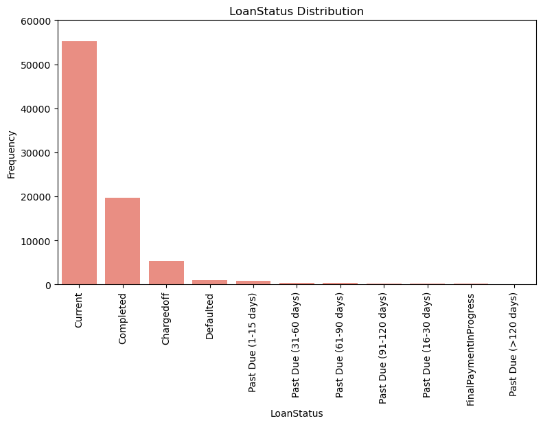

```python
# checking the status of all loan at the moment
x_counts = df['LoanStatus'].value_counts()
t_order = x_counts.index
plt.figure(figsize=[9, 5]);
sns.countplot(data =df, x = 'LoanStatus', color = 'Salmon', order= t_order);
plt.title('LoanStatus Distribution');
plt.ylabel('Frequency');
plt.ylim(0, 60000)
plt.xlabel('LoanStatus');
plt.xticks(rotation=90);
df['LoanStatus'].value_counts()
```

The vast majority of loans are current as of the end of this data set, and a sizeable minority no longer exist.

Question 3: What's the best rating

```
C     17951
B     15329
A     14336
D     14077
E      9621
HR     6876
AA     5317
Name: ProsperRating (Alpha), dtype: int64
```

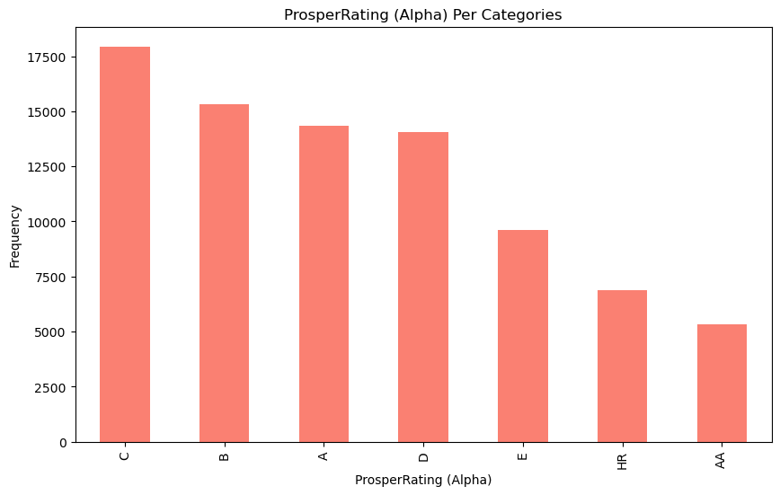

```python
# Plot to reveal the creditgrade distribution
plt.figure(figsize=[10, 6])
df['ProsperRating (Alpha)'].value_counts().plot.bar(color='Salmon' )
plt.xlabel('ProsperRating (Alpha)')
plt.ylabel('Frequency')
plt.title('ProsperRating (Alpha) Per Categories');
df['ProsperRating (Alpha)'].value_counts()
```

Question 4: what's the income range distribution count

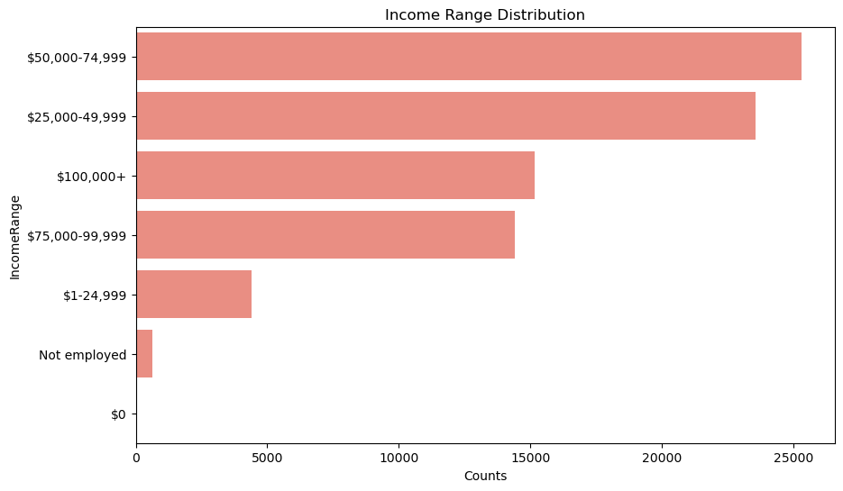

```python
# Distribution based on income range
plt.figure(figsize=[10, 6])
sns.countplot(data = df, y = 'IncomeRange', color = 'Salmon')
#plt.xticks(t_props * n_pokemon, t_names)
plt.xlabel('Counts')
plt.title('Income Range Distribution')
plt.show()
```

The income spectrum of loan applicants is displayed here. A majority of borrowers have annual incomes between $20,000 and $75,000, as shown by the data.

Question 5: Which loan term performs better

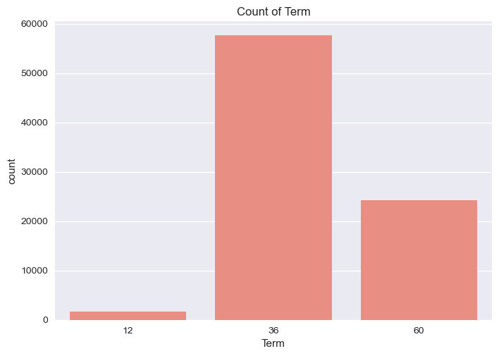

```python
plt.style.use("seaborn")
sns.countplot(data=df,x='Term', color="Salmon")
plt.title('Count of Term');
```

Most loans fall within the three-year range, followed by the five-year range

## Bivariate Exploration

Now, let's look for some correlations between our two target variables, borrower APR and Prosper rating, to see if we can draw any conclusions about the two. During our univariate study, we employed a method similar to descriptive statistics to gain a feel for the distribution of our numerical variables.

Question 1: Relationship using scattered plot for numeric variables

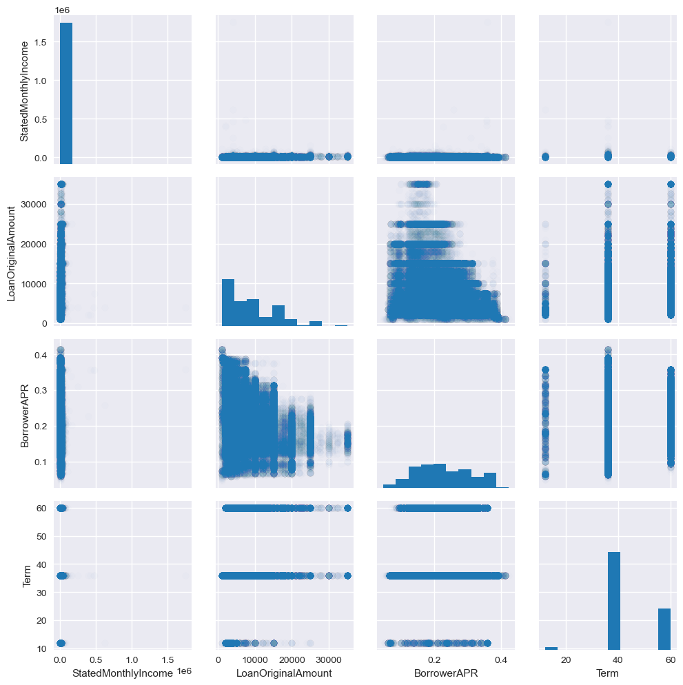

```python
# Store numeric column names in a list
numeric_cols = ['DebtToIncomeRatio', 'StatedMonthlyIncome', 'LoanOriginalAmount', 'BorrowerAPR', 'Term']

# Create a scatterplot of each numeric variable against the other
fig = sns.PairGrid(df[numeric_cols])
fig.map_diag(plt.hist, color = colors[1])
fig.map_offdiag(plt.scatter,color = colors[1], alpha=0.01);
```

It would indicate that the original amount borrowed has a moderately negative link with the borrower's annual percentage rate (APR). This suggests that larger loans may be offered at annual percentage rates that are lower than those offered for smaller loans.

Question 2: Relationship of Numeric variable using Heatmap

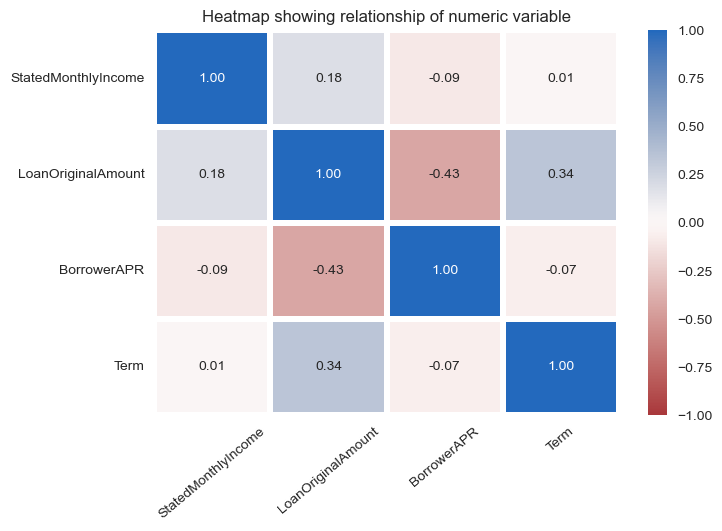

```python
# Visualize the correlation between the numeric variables with a heatmap
plt.figure(figsize= (7.5, 5))
sns.heatmap(data=df[numeric_cols].corr(), annot=True, fmt='.2f',
            cmap='vlag_r', vmin=-1, vmax=1, linewidth=3)
plt.xticks(rotation=40)
plt.title('Heatmap showing relationship of numeric variable');
```

It seems there is a weak negative relationship (-0.43) between the initial loan amount and the Borrower APR. Therefore, it's possible that larger loans would have lower APRs than smaller ones. The LoanOriginalAmount has a mildly positive connection with the LoanTerm (0.34). A bigger loan amount may necessitate a longer period in order for the borrower to repay the debt.

Question 3:Showing relationship between ProsperRating and BorrowerAPR

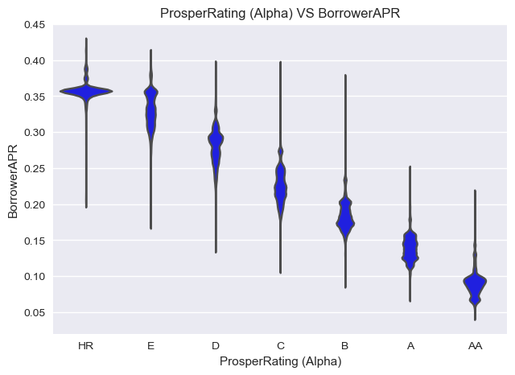

```python
# relationship between ProsperRating (Alpha) and BorrowerAPR and Term
plt.figure(figsize = [16, 5])
plt.subplot(1, 2, 1)
sns.violinplot(data=df, x='ProsperRating (Alpha)', y='BorrowerAPR', color='Blue', inner=None,
              order=['HR', 'E', 'D', 'C', 'B', 'A', 'AA']);
plt.title('ProsperRating (Alpha) VS BorrowerAPR');
```

The ProsperRating and BorrowerAPR are inversely related. A borrower's annual percentage rate (APR) is affected by their ProsperRating. The lower the BorrowerAPR, the higher the BorrowerProsper rating.

Question 4:Showing relationship between BorrowerAPR and Term

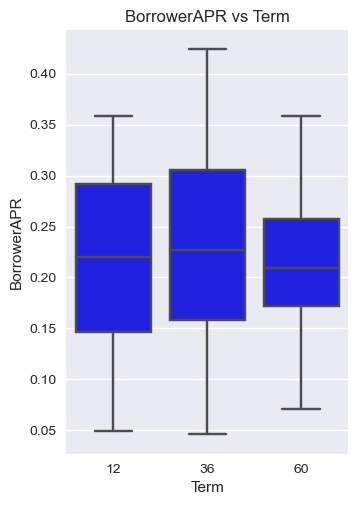

```python
plt.subplot(1, 2, 2)
sns.boxplot(data=df, x='Term', y='BorrowerAPR', color='Blue')
plt.title('BorrowerAPR vs Term');
```

Question 5: What's the relationship between estimated return and borrowerAPR

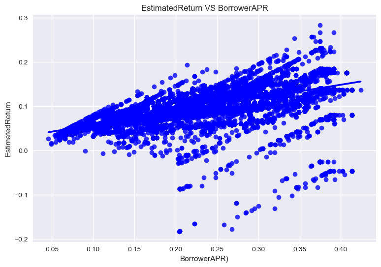

```python
# What's the relationship between estimated return and borrowerAPR
plt.figure(figsize = [9,6])
sns.regplot(data =df, x = 'BorrowerAPR', y = 'EstimatedReturn',color='Blue');
plt.xlabel('BorrowerAPR)')
plt.ylabel('EstimatedReturn')
plt.title('EstimatedReturn VS BorrowerAPR')
plt.show()
```

The regression line in a scatter plot showing a positive correlation between the two variables.

## Conclusions

The dataset used in this study is comprised of 81 variables and 113,937 observations, all drawn from Prosper loan applications. Due to the large number of potential factors, it will take a considerable time for cleaning. Therefore, I'm only interested in a specific part of the data, so I'm only looking at a subset of the available variables. To understand the data, the dataset was evaluated for insight into its constituent variables using the info and describe functions. Afterwards, the BorrowerAPR became the primary emphasis of the probe.

Some columns were eliminated during data wrangling since they contained information that would not contribute to the analysis. All fields were inspected for null values, and columns with more than 50% blanks were eliminated.

# Limitation

The amount of missing information in our data set was quite large. Once we eliminated the blanks from the data, we were left with around 75% of the original data. This is still a respectable sample size, but it raises questions about how widely we can extrapolate the results of our investigation. Since the focus of this research has been on investigating possible associations between factors, it is not possible to state with any degree of certainty that any given factor is responsible for any given outcome. A mere observational research was conducted. A carefully designed experiment is necessary to prove a causal connection.